# Python Series 02

## The goal of this notebook is to plot sinus signal as somethin useful

Math fotmula of the sinusoid = y(t) = A * sin (2 pi ft + φ)

A = amplitude f = frequency of the signal (in Hz) t = time (seconds) φ = initial phase

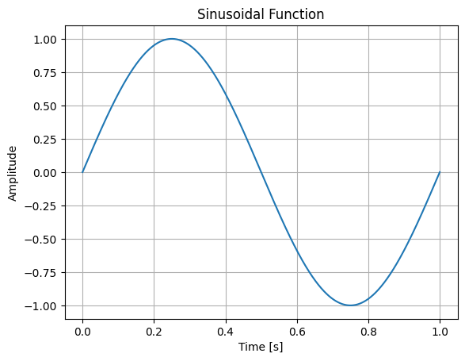

```python
import numpy as np
import matplotlib.pyplot as plt

#Create a numpy array called t that contains 1000 values from 0 to 1 (t is for time)
t = np.array([i/1000 for i in range(1001)])

#Create a numpy array called s that contains the values of a sine function of t (s is for signal)
s = np.sin(2 * np.pi * 1 * t) # 1 Hz sine wave

#Plot the signal s as a function of time t
plt.plot(t, s)
plt.xlabel('Time [s]')
plt.ylabel('Amplitude')
plt.title('Sinusoidal Function')
plt.grid()
plt.savefig('sine_wave.png')
plt.show()
```

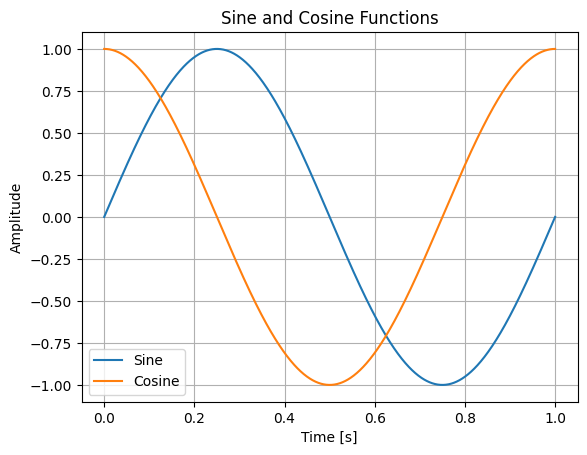

```python
import numpy as np
import matplotlib.pyplot as plt

# Create a numpy array called t that contains 1000 values from 0 to 1
t = np.linspace(0, 1, 1000)

# Create sine and cosine signals
s = np.sin(2 * np.pi * 1 * t)  # 1 Hz sine wave
c = np.cos(2 * np.pi * 1 * t)  # 1 Hz cosine wave


# Plot both signals on the same axis
plt.plot(t, s, label="Sine")
plt.plot(t, c, label="Cosine")

# Labels, title, grid
plt.xlabel("Time [s]", color="black")
plt.ylabel("Amplitude", color="black")
plt.title("Sine and Cosine Functions")
plt.grid(True)

# Legend
plt.legend()

# Save as PDF
plt.savefig("sine_cosine.pdf")
plt.show()
```

# Creation of the sinusoid

```python
import numpy as np
import matplotlib.pyplot as plt

def sinusoid (amplitude : float, frequency: float, duration: float, num_points: int=1000, phase: float = 0.0):
#     Create a sinusoidal signal

#     Parameters
#     ---------
# float = real number with decimal

#     amplitud :(maximal amplitude of the sinus)
#     frequency : (frequency in Hz)
#     duration : total time of the signal in seconds
#     num_points : number of the signal points (default is 1000)
#     phase : inital phase in radians

#     Returns
#     -------
#     np.ndarray = sinusoid signal evaluated on a linear vector

    t=np.linspace (0, duration, num_points) # time vector
    x= amplitude * np.sin(2*np.pi*frequency*t+phase)
    return x,t
```

# Creating two signals with different frequencies

```python
# Parameters definition
amplitude = 1.0
duration = 1.0  # seconds
num_points = 1000

# Different frequencies
freq1 = 1  # Hz
freq2 = 3  # Hz

# Signal generation
sine_wave_1, t = sinusoid(amplitude, freq1, duration, num_points)
sine_wave_2, _ = sinusoid(amplitude, freq2, duration, num_points)  # time vector already calculated
```

# Plot the two signals

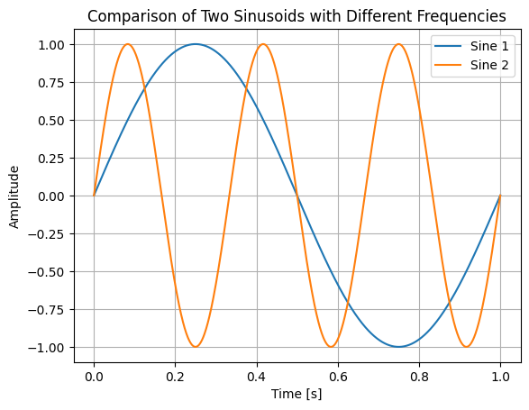

```python
# Plot the two signals
plt.plot(t, sine_wave_1, label=f"Sine 1")
plt.plot(t, sine_wave_2, label=f"Sine 2")

# Labels and titles
plt.xlabel("Time [s]")
plt.ylabel("Amplitude")
plt.title("Comparison of Two Sinusoids with Different Frequencies")
plt.grid(True)
plt.legend()

# Saving the figure
plt.savefig("two_sinusoids.pdf")
plt.show()
```

# 3.1 Even or odd

### Even number : is an integer that is divisible by 2 without a remainder

```python
import numpy as np

# create a series of number from 0 to 10 and print if it is even or odd
numbers = np.arange(0, 11) # create a numpy array from 0 to 10

#create a loop
for number in numbers : # loop through each number in the array
    if number % 2 == 0: # check if the number is even by dividing by 2 and checking the remainder
        print(f"{number} is even")
    else:
        print(f"{number} is odd")
```

```
0 is even
1 is odd
2 is even
3 is odd
4 is even
5 is odd
6 is even
7 is odd
8 is even
9 is odd
10 is even
```

# Multiple or not

### A **multiple** of a number (m) is any integer that can be expressed as the product of (m) and another integer (k).

Mathematically, a number (n) is a multiple of (m) if:

[ n = m \cdot k \quad \text{where } k \text{ is an integer.} ]

```python
import numpy as np

# create a series of numbers from 0 to 20
numbers = np.arange(0, 21) # create a numpy array from 0 to 20

#create a loop to check if multiples of 3 or 5
def check_multiple(number: int, m: int):
    if number % m == 0:
        print(f"{number} is a multiple of {m}")
    else:
        print(f"{number} is NOT a multiple of {m}")

numbers = range(0, 21)  # 0 à 20
for number in numbers:
    check_multiple(number, 3)  # vérifie multiple de 3
    check_multiple(number, 5)  # vérifie multiple de 5
    print()  # ligne vide pour séparer les nombres
```

```
0 is a multiple of 3
0 is a multiple of 5

1 is NOT a multiple of 3
1 is NOT a multiple of 5

2 is NOT a multiple of 3
2 is NOT a multiple of 5

3 is a multiple of 3
3 is NOT a multiple of 5

4 is NOT a multiple of 3
4 is NOT a multiple of 5

5 is NOT a multiple of 3
5 is a multiple of 5

6 is a multiple of 3
6 is NOT a multiple of 5

7 is NOT a multiple of 3
7 is NOT a multiple of 5

8 is NOT a multiple of 3
8 is NOT a multiple of 5

9 is a multiple of 3
9 is NOT a multiple of 5

10 is NOT a multiple of 3
10 is a multiple of 5

11 is NOT a multiple of 3
11 is NOT a multiple of 5

12 is a multiple of 3
12 is NOT a multiple of 5

13 is NOT a multiple of 3
13 is NOT a multiple of 5

14 is NOT a multiple of 3
14 is NOT a multiple of 5

15 is a multiple of 3
15 is a multiple of 5

16 is NOT a multiple of 3
16 is NOT a multiple of 5

17 is NOT a multiple of 3
17 is NOT a multiple of 5

18 is a multiple of 3
18 is NOT a multiple of 5

19 is NOT a multiple of 3
19 is NOT a multiple of 5

20 is NOT a multiple of 3
20 is a multiple of 5
```

# Time to compute this a function

```python
# Function of n who check if it a multiple of m

def print_multiple(n: int, m: int):
    if n % m == 0:
        print(f"{n} is a multiple of {m}")
    else:
        print(f"{n} is NOT a multiple of {m}")

# Examples
print_multiple(10, 3)
print_multiple(10, 5)
print_multiple(256, 8)
```

```
10 is NOT a multiple of 3
10 is a multiple of 5
256 is a multiple of 8
```

```python
# function that takes as input a series of integers m, so to return a list of booleans indicating if each number is a mutliple of m

def multiple_of_m(numbers, m) :
    for n in numbers :
        if n % m == 0 :
            print (True)
        else :
            print (False)
#Examples
numbers = range (0, 21)  # 0 à 20
print(multiple_of_m(numbers, 5))  # vérifie multiple de 5
```

```
True
False
False
False
False
True
False
False
False
False
True
False
False
False
False
True
False
False
False
False
True
None
```

# Prime or not

### A **prime number** is an integer greater than 1 that has **exactly two positive divisors**: 1 and itself.

Mathematically, a number (p) is prime if:

[ \text{Divisors of } p = {1, p} ]

```python
def is_prime(n) :
    if n < 2 :
        return False
    for i in range(2, n) :
        if n % i == 0 :
            return False
    return True
numbers = range(0, 200)  # 0 à 200
primes_200 = [n for n in numbers if is_prime(n)]
print(primes_200)  # Affiche les nombres premiers entre 0 et 20
```

```
[2, 3, 5, 7, 11, 13, 17, 19, 23, 29, 31, 37, 41, 43, 47, 53, 59, 61, 67, 71, 73, 79, 83, 89, 97, 101, 103, 107, 109, 113, 127, 131, 137, 139, 149, 151, 157, 163, 167, 173, 179, 181, 191, 193, 197, 199]
```

# Same function but for 200 000 000

```python
import sys
!{sys.executable} -m pip install sympy
```

```python
from sympy import primepi

# Compter les nombres premiers <= 200 millions
count = primepi(200000000)

# Convertir en int pour pouvoir utiliser la virgule dans l'affichage
print(f"In [0 .. 200 000 000] : {int(count):,} primes found")
```

```
In [0 .. 200 000 000] : 11,078,937 primes found
```

# Improvements thanks to the pull request

In the first graphic (sinusoidal function), I had the formula s = np.sin(2 * np.pi * 2 * t). Alexis adviced me to modify it and replace the second "2" by a "1" to have only one sinusoidal wave, so that the blue line will be the same as the one in the next two graphs ('Sine and cosine function' and 'Comparison of Two Sinusoids with Different Frequencies').